## 数据预处理

好的数据质量，应该满足“完全合一”

- 完整性：数据是否存在空值，字段是否完善，是否有漏掉
- 全面性：观察某一列的全部数值及特征值，是否存在单位、字段名与数值不匹配
- 合法性：数据的类型、内容、大小的合法性。
- 唯一性：数据是否存在重复记录

```python
import numpy as np
import pandas as pd

#忽略警号消息
import warnings
warnings.filterwarnings("ignore")

import matplotlib
import matplotlib.pyplot as plt
%matplotlib inline
#设置中文显示
plt.rcParams['font.sans-serif']='SimHei'
plt.rcParams['font.size']=14
#解决负号问题
matplotlib.rcParams['axes.unicode_minus'] =False
```

### 缺失值处理

数据缺失主要包括记录缺失和字段信息缺失等情况，其对数据分析会有较大影响，导致结果不确定性更加显著。 缺失值处理方法一般可分为：删除、统计值填充、统一值填充、前后向值填充、插值法填充、建模预测填充和具体分析7种方法。

```python
# 判断是否有缺失值数据 - isnull，notnull
# isnull：缺失值为True，非缺失值为False
# notnull：缺失值为False，非缺失值为True

s = pd.Series([12,33,45,23,np.nan,np.nan,66,54,np.nan,99])
df = pd.DataFrame({'value1':[12,33,45,23,np.nan,np.nan,66,54,np.nan,99,190],
                  'value2':['a','b','c','d','e',np.nan,np.nan,'f','g',np.nan,'g']})
# 创建数据

print(s.isnull())  # Series直接判断是否是缺失值，返回一个Series
print(df.notnull())  # Dataframe直接判断是否是缺失值，返回一个Series
print(df['value1'].notnull())  # 通过索引判断
print('------')

s2 = s[s.isnull() == False]
df2 = df[df['value2'].notnull()]    # 注意和 df2 = df[df['value2'].notnull()] ['value1'] 的区别
print(s2)
print(df2)
```

```
0    False
1    False
2    False
3    False
4     True
5     True
6    False
7    False
8     True
9    False
dtype: bool
    value1  value2
0     True    True
1     True    True
2     True    True
```

[output cut: 38 more lines]

#### 删除缺失值 - dropna

```python
s = pd.Series([12,33,45,23,np.nan,np.nan,66,54,np.nan,99])
df = pd.DataFrame({'value1':[12,33,45,23,np.nan,np.nan,66,54,np.nan,99,190],
                  'value2':['a','b','c','d','e',np.nan,np.nan,'f','g',np.nan,'g']})
# 创建数据

s.dropna(inplace = True)
df2 = df['value1'].dropna()
print(s)
print(df2)
# drop方法：可直接用于Series，Dataframe
# 注意inplace参数，默认False → 生成新的值
```

```
0    12.0
1    33.0
2    45.0
3    23.0
6    66.0
7    54.0
9    99.0
dtype: float64
0      12.0
1      33.0
2      45.0
3      23.0
6      66.0
7      54.0
9      99.0
10    190.0
Name: value1, dtype: float64
```

#### 填充

使用fillna、replace方法

##### 统一值填充

- 所谓统一值是指自定义指定的某一个常数。
- 常用的统一值有：空值、0、正无穷、负无穷或者自定义的其他值
- 注意事项：当特征之间存在很强的类别信息时，需要进行类内统计，效果比直接处理会更好。
- 比如在填充身高时，需要先对男女进行分组聚合之后再进行统一值填充处理。 (男士的身高缺失值使用统一填充值就自定为常数1.70，女士自定义常数1.60)。

##### 统计值填充

- 统计值一般泛指平均值、中位数、众数、最大值、最小值等，具体使用哪一种统计值要根据具体问题具体分析。
- 当特征之间存在很强的类别信息时，需要进行类内统计，效果比直接处理会更好。
- 比如在填充身高时，需要先对男女进行分组聚合之后再进行统计值填充处理(男士的一般平均身高1.70，女士一般1.60)。

##### 前后向值填充

前后向值填充是指使用缺失值的前一个或者后一个的值作为填充值进行填充。

##### 插值法填充

所谓的插值法，就是在X范围区间中挑选一个或者自定义一个数值，然后代进去插值模型公式当中，求出数值作为缺失值的数据。

##### 预测填充

- 把需要填充缺失值的某一列特征(Feature_A)作为新的标签(Label_A)
- 然后找出与 Label_A 相关性较强的特征作为它的模型特征
- 把 Label_A 非缺失值部分作为训练集数据，而缺失值部分则作为测试集数据
- 若 Label_A 的值属于连续型数值，则进行回归拟合；若是类别(离散)型数值，则进行分类学习
- 将训练学习到评分和泛化能力较好的模型去预测测试集，从而填充好缺失值

##### 统一值填充

```python
# 创建数据
s = pd.Series([12,33,45,23,np.nan,np.nan,66,54,np.nan,99])
df = pd.DataFrame({'value1':[12,33,45,23,np.nan,np.nan,66,54,np.nan,99,190],
                  'value2':['a','b','c','d','e',np.nan,np.nan,'f','g',np.nan,'g']})


s.fillna(0,inplace = True)
print(s)
print('------')
# s.fillna(value=None, method=None, axis=None, inplace=False, limit=None, downcast=None, **kwargs)
# value：填充值
# 注意inplace参数

df['value1'].fillna(method = 'pad',inplace = True)
print(df)
print('------')
# method参数：
# pad / ffill → 用之前的数据填充
# backfill / bfill → 用之后的数据填充
```

```
0    12.0
1    33.0
2    45.0
3    23.0
4     0.0
5     0.0
6    66.0
7    54.0
8     0.0
9    99.0
dtype: float64
------
    value1 value2
0     12.0      a
1     33.0      b
2     45.0      c
3     23.0      d
4     23.0      e
5     23.0    NaN
6     66.0    NaN
7     54.0      f
8     54.0      g
9     99.0    NaN
10   190.0      g
------
```

```python
s = pd.Series([1,1,1,1,2,2,2,3,4,5,np.nan,np.nan,66,54,np.nan,99])
s.replace(np.nan,'缺失数据',inplace = True)
print(s)
print('------')
# df.replace(to_replace=None, value=None, inplace=False, limit=None, regex=False, method='pad', axis=None)
# to_replace → 被替换的值
# value → 替换值
```

```
0        1
1        1
2        1
3        1
4        2
5        2
6        2
7        3
8        4
9        5
10    缺失数据
11    缺失数据
12      66
13      54
14    缺失数据
15      99
dtype: object
------
```

##### 均值/中位数/众数插补

```python
s = pd.Series([1,2,3,np.nan,3,4,5,5,5,5,np.nan,np.nan,6,6,7,12,2,np.nan,3,4])
#print(s)
print('------')
# 创建数据

u = s.mean()     # 均值
me = s.median()  # 中位数
mod = s.mode()   # 众数
print('均值为：%.2f, 中位数为：%.2f' % (u,me))
print('众数为：', mod.tolist())
print('------')
# 分别求出均值/中位数/众数

s.fillna(u,inplace = True)
print(s)
# 用均值填补
```

```
------
均值为：4.56, 中位数为：4.50
众数为： [5.0]
------
0      1.0000
1      2.0000
2      3.0000
3      4.5625
4      3.0000
5      4.0000
6      5.0000
7      5.0000
8      5.0000
9      5.0000
10     4.5625
11     4.5625
12     6.0000
13     6.0000
14     7.0000
15    12.0000
16     2.0000
17     4.5625
18     3.0000
19     4.0000
dtype: float64
```

##### 临近值插补

```python
s = pd.Series([1,2,3,np.nan,3,4,5,5,5,5,np.nan,np.nan,6,6,7,12,2,np.nan,3,4])
#print(s)
print('------')
# 创建数据

s.fillna(method = 'ffill',inplace = True)
print(s)
# 用前值插补
```

```
------
0      1.0
1      2.0
2      3.0
3      3.0
4      3.0
5      4.0
6      5.0
7      5.0
8      5.0
9      5.0
10     5.0
11     5.0
12     6.0
13     6.0
14     7.0
15    12.0
16     2.0
17     2.0
18     3.0
19     4.0
dtype: float64
```

##### 插值法 —— 拉格朗日插值法

```python
from scipy.interpolate import lagrange
x = [3, 6, 9]
y = [10, 8, 4]
print(lagrange(x,y))
print(type(lagrange(x,y)))
# 的输出值为的是多项式的n个系数
# 这里输出3个值，分别为a0,a1,a2
# y = a0 * x**2 + a1 * x + a2 → y = -0.11111111 * x**2 + 0.33333333 * x + 10

print('插值10为：%.2f' % lagrange(x,y)(10))
print('------')
# -0.11111111*100 + 0.33333333*10 + 10 = -11.11111111 + 3.33333333 +10 = 2.22222222
```

```
         2
-0.1111 x + 0.3333 x + 10
<class 'numpy.poly1d'>
插值10为：2.22
------
```

##### 具体分析

缺失本身是包含信息的，所以需要根据不同应用场景下缺失值可能包含的信息进行合理填充。

- “年收入”：商品推荐场景下填充平均值，借贷额度场景下填充最小值；
- “行为时间点”：填充众数；
- “价格”：商品推荐场景下填充最小值，商品匹配场景下填充平均值；
- “人体寿命”：保险费用估计场景下填充最大值，人口估计场景下填充平均值；
- “驾龄”：没有填写这一项的用户可能是没有车，为它填充为0较为合理；
- ”本科毕业时间”：没有填写这一项的用户可能是没有上大学，为它填充正无穷比较合理；
- “婚姻状态”：没有填写这一项的用户可能对自己的隐私比较敏感，应单独设为一个分类，如已婚1、未婚0、未填-1。

### 离群值处理

异常值是指样本中的个别值，其数值明显偏离其余的观测值。

异常值也称离群点，异常值的分析也称为离群点的分析

异常值分析 → 3σ原则 / 箱型图分析

异常值处理方法 → 删除 / 修正填补

#### 标准差法（3σ原则）

如果数据服从正态分布，异常值被定义为与平均值的偏差超过3倍标准差的值 → p(|x - μ| > 3σ) ≤ 0.003

```
均值为：0.818，标准差为：100.716
------
异常值共23条
```

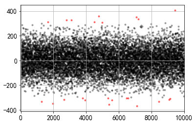

```python
# 创建数据
data = pd.Series(np.random.randn(10000)*100)

# 正态性检验
u = data.mean()  # 计算均值
std = data.std()  # 计算标准差
print('均值为：%.3f，标准差为：%.3f' % (u,std))
print('------')

# 筛选出异常值error、剔除异常值之后的数据data_c
error = data[np.abs(data - u) > 3*std]
data_c = data[np.abs(data - u) <= 3*std]
print('异常值共%i条' % len(error))

# 图表表达
plt.scatter(data_c.index,data_c,color = 'k',marker='.',alpha = 0.3)
plt.scatter(error.index,error,color = 'r',marker='.',alpha = 0.5)
plt.xlim([-10,10010])
plt.grid()
```

#### 箱型图法

```
count    10000.000000
mean        -0.444144
std        100.150952
min       -376.150329
25%        -67.692158
50%         -0.474535
75%         68.970372
max        443.713382
dtype: float64
```

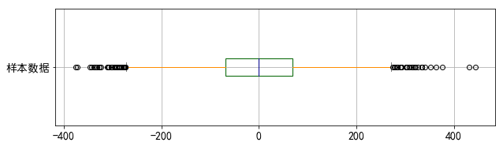

```python
# 创建数据
data = pd.Series(np.random.randn(10000)*100)
# 基本统计量
s=data.describe()
print(s)
# 箱型图看数据分布情况
fig = plt.figure(figsize = (10,6))
ax1 = fig.add_subplot(2,1,1)
color = dict(boxes='DarkGreen', whiskers='DarkOrange', medians='DarkBlue', caps='Gray')
data.plot.box(vert=False, grid = True,color = color,ax = ax1,label = '样本数据')
```

```
分位差为：136.663，下限为：-272.686，上限为：273.964
------
异常值共64条
```

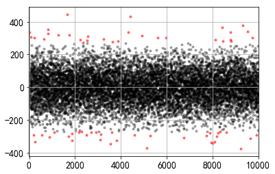

```python
# 计算分位差
q1 = s['25%']
q3 = s['75%']
iqr = q3 - q1
mi = q1 - 1.5*iqr
ma = q3 + 1.5*iqr
print('分位差为：%.3f，下限为：%.3f，上限为：%.3f' % (iqr,mi,ma))
print('------')

# 筛选出异常值error、剔除异常值之后的数据data_c
error = data[(data < mi) | (data > ma)]
data_c = data[(data >= mi) & (data <= ma)]
print('异常值共%i条' % len(error))

# 图表表达
ax2 = fig.add_subplot(2,1,2)
plt.scatter(data_c.index,data_c,color = 'k',marker='.',alpha = 0.3)
plt.scatter(error.index,error,color = 'r',marker='.',alpha = 0.5)
plt.xlim([-10,10010])
plt.grid()
```

### 数据归一化/标准化

数据的标准化（normalization）是将数据按比例缩放，使之落入一个小的特定区间。

在某些比较和评价的指标处理中经常会用到，去除数据的单位限制，将其转化为无量纲的纯数值，便于不同单位或量级的指标能够进行比较和加权

最典型的就是数据的归一化处理，即将数据统一映射到[0,1]区间上

0-1标准化 / Z-score标准化

#### 为什么我们要进行归一化/标准化？

特征的大小相差较大，容易影响（支配）目标结果，使得一些算法无法学习到其它的特征。

##### 0-1标准化

将数据的最大最小值记录下来，并通过Max-Min作为基数（即Min=0，Max=1）进行数据的归一化处理

x = (x - Min) / (Max - Min)

```python
df = pd.DataFrame({"value1":np.random.rand(10)*20,
                  'value2':np.random.rand(10)*100})
print(df.head())
print('------')
# 创建数据

def data_norm(df,*cols):
    df_n = df.copy()
    for col in cols:
        ma = df_n[col].max()
        mi = df_n[col].min()
        df_n[col + '_n'] = (df_n[col] - mi) / (ma - mi)
    return(df_n)
# 创建函数，标准化数据

df_n = data_norm(df,'value1','value2')
print(df_n.head())
# 标准化数据
```

```
      value1     value2
0  18.904901  54.524271
1   7.190567  86.492907
2  12.553686  62.669266
3   1.412576  49.506689
4  13.264112  31.537285
------
      value1     value2  value1_n  value2_n
0  18.904901  54.524271  1.000000  0.433865
1   7.190567  86.492907  0.330316  0.833521
2  12.553686  62.669266  0.636914  0.535690
3   1.412576  49.506689  0.000000  0.371137
4  13.264112  31.537285  0.677528  0.146492
```

注：sklearn库中有直接标准化的函数

#### Z-score标准化

当前用得最多的数据标准化方式

Z分数（z-score）,是一个分数与平均数的差再除以标准差的过程 → z=(x-μ)/σ，其中x为某一具体分数，μ为平均数，σ为标准差

Z值的量代表着原始分数和母体平均值之间的距离，是以标准差为单位计算。在原始分数低于平均值时Z则为负数，反之则为正数

数学意义：一个给定分数距离平均数多少个标准差?

什么情况用Z-score标准化？在分类、聚类算法中，需要使用距离来度量相似性的时候，Z-score表现更好

```python
df = pd.DataFrame({"value1":np.random.rand(10) * 100,
                  'value2':np.random.rand(10) * 100})
print(df.head())
print('------')
# 创建数据

def data_Znorm(df, *cols):
    df_n = df.copy()
    for col in cols:
        u = df_n[col].mean()
        std = df_n[col].std()
        df_n[col + '_Zn'] = (df_n[col] - u) / std
    return(df_n)
# 创建函数，标准化数据

df_z = data_Znorm(df,'value1','value2')
u_z = df_z['value1_Zn'].mean()
std_z = df_z['value1_Zn'].std()
print(df_z)
print('标准化后value1的均值为:%.2f, 标准差为：%.2f' % (u_z, std_z))
# 标准化数据
# 经过处理的数据符合标准正态分布，即均值为0，标准差为1
```

```
      value1     value2
0  10.447945  18.365564
1  19.622155  79.322441
2  66.960266  71.519824
3  52.942727  12.750959
4  23.873521  65.110246
------
      value1     value2  value1_Zn  value2_Zn
0  10.447945  18.365564  -0.752765  -0.854205
1  19.622155  79.322441  -0.430205   0.974820
2  66.960266  71.519824   1.234174   0.740700
3  52.942727  12.750959   0.741326  -1.022672
4  23.873521  65.110246  -0.280730   0.548380
5   4.104172  97.716165  -0.975808   1.526727
6   1.054042  29.241919  -1.083049  -0.527858
7  11.730754   6.211254  -0.707662  -1.218898
8  83.305047  17.020503   1.808847  -0.894564
9  44.539476  71.082227   0.445873   0.727570
标准化后value1的均值为:-0.00, 标准差为：1.00
```

### 连续变量离散化

连续属性变换成分类属性，即连续属性离散化 在数值的取值范围内设定若干个离散划分点，将取值范围划分为一些离散化的区间，最后用不同的符号或整数值代表每个子区间中的数据值

等宽法 / 等频法

#### 等宽法

将数据均匀划分成n等份，每份的间距相等

```python
# 有一组人员年龄数据，希望将这些数据划分为“18到25”,“26到35”,“36到60”,“60以上”
ages=[20,22,25,27,21,23,37,31,61,45,41,32]

# 返回的是一个特殊的Categorical对象
bins = [18,25,35,60,100]
cats = pd.cut(ages,bins)
print(cats)
print('-'*30)
print(type(cats))
```

```
[(18, 25], (18, 25], (18, 25], (25, 35], (18, 25], ..., (25, 35], (60, 100], (35, 60], (35, 60], (25, 35]]
Length: 12
Categories (4, interval[int64]): [(18, 25] < (25, 35] < (35, 60] < (60, 100]]
------------------------------
<class 'pandas.core.arrays.categorical.Categorical'>
```

```python
print(cats.codes, type(cats.codes))  # 0-3对应分组后的四个区间，用代号来注释数据对应区间，结果为ndarray
print('-'*30)
print(cats.categories, type(cats.categories))  # 四个区间，结果为index
print('-'*30)
print(pd.value_counts(cats))  # 按照区间计数
```

```
[0 0 0 1 0 0 2 1 3 2 2 1] <class 'numpy.ndarray'>
------------------------------
IntervalIndex([(18, 25], (25, 35], (35, 60], (60, 100]],
              closed='right',
              dtype='interval[int64]') <class 'pandas.core.indexes.interval.IntervalIndex'>
------------------------------
(18, 25]     5
(35, 60]     3
(25, 35]     3
(60, 100]    1
dtype: int64
```

```python
# 通过right函数修改闭端，默认为True
print(pd.cut(ages,[18,26,36,61,100],right=False))
```

```
[[18, 26), [18, 26), [18, 26), [26, 36), [18, 26), ..., [26, 36), [61, 100), [36, 61), [36, 61), [26, 36)]
Length: 12
Categories (4, interval[int64]): [[18, 26) < [26, 36) < [36, 61) < [61, 100)]
```

```python
# 可以设置自己的区间名称，用labels参数
group_names=['Youth','YoungAdult','MiddleAged','Senior']
print(pd.cut(ages,bins,labels=group_names))
```

```
['Youth', 'Youth', 'Youth', 'YoungAdult', 'Youth', ..., 'YoungAdult', 'Senior', 'MiddleAged', 'MiddleAged', 'YoungAdult']
Length: 12
Categories (4, object): ['Youth' < 'YoungAdult' < 'MiddleAged' < 'Senior']
```

```python
df = pd.DataFrame({'ages':ages})
cats = pd.cut(list(df['ages']),bins)
df['group_name'] = cats

print(df)
print('-'*30)
print(df['group_name'].value_counts())
```

```
    ages group_name
0     20   (18, 25]
1     22   (18, 25]
2     25   (18, 25]
3     27   (25, 35]
4     21   (18, 25]
5     23   (18, 25]
6     37   (35, 60]
7     31   (25, 35]
8     61  (60, 100]
9     45   (35, 60]
10    41   (35, 60]
11    32   (25, 35]
------------------------------
(18, 25]     5
(35, 60]     3
(25, 35]     3
(60, 100]    1
Name: group_name, dtype: int64
```

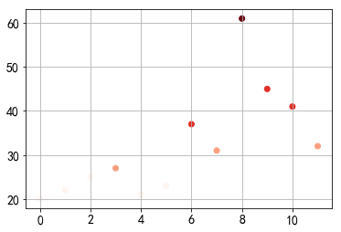

```python
# 用散点图表示，其中颜色按照codes分类
# 注意codes是来自于Categorical对象
plt.scatter(df.index,df['ages'],cmap = 'Reds',c = cats.codes)
plt.grid()
```

#### 等频法

以相同数量的记录放进每个区间

```python
# qcut → 根据样本分位数对数据进行划分，得到大小基本相等的区间
data = np.random.randn(1000)

df = pd.DataFrame({"data":data})
cats = pd.qcut(list(df['data']),4)
df['group_name'] = cats

print(df.head())
print('-'*30)
print(df['group_name'].value_counts())
```

```
       data                     group_name
0  0.093309               (-0.0338, 0.661]
1  2.071607                 (0.661, 3.089]
2  0.278672               (-0.0338, 0.661]
3 -0.019181               (-0.0338, 0.661]
4 -1.135834  (-3.6069999999999998, -0.668]
------------------------------
(0.661, 3.089]                   250
(-0.0338, 0.661]                 250
(-0.668, -0.0338]                250
(-3.6069999999999998, -0.668]    250
Name: group_name, dtype: int64
```

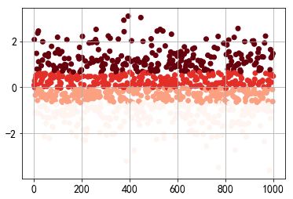

```python
# 用散点图表示，其中颜色按照codes分类
# 注意codes是来自于Categorical对象
plt.scatter(df.index,df['data'],cmap = 'Reds',c = cats.codes)
plt.grid()
```

### 类别数据处理

#### LabelEncoder通常用于处理类别间具有大小关系的数据

- 例如成绩，可以分为低、中、高三档，并且存在“高>中>低”的排序关系。
- 序号编码会按照大小关系对类别型特征赋予一个数值ID，例如高表示为3、中表示为2、低表示为1，转换后依然保留了大小关系。
- 对于不具有大小关系的类别数据不建议使用。

#### one-hot

##### one-hot通常用于处理类别间不具有大小关系的特征

例如血型，一共有4个取值（A型血、B型血、AB型血、O型血），one-hot编码会把血型变成一个4维稀疏向量，A型血表示为（1, 0,0, 0），B型血表示为（0, 1, 0, 0），AB型表示为（0, 0,1, 0），O型血表示为（0, 0, 0, 1）。

### 数据变换

#### 概念及工作原理

简单常用的函数变换法(一般针对于连续数据)：

- 平方(小数值—>大数值)
- 开平方(大数值—>小数值)
- 指数
- 对数
- 差分

#### 优缺点

优点：

- 将不具有正态分布的数据变换成具有正态分布的数据
- 对于时间序列分析，有时简单的对数变换和差分运算就可以将非平稳序列转换成平稳序列

#### 应用场景及意义

应用场景：

- 数据不呈正态分布时可运用
- 当前特征数据不利于被模型捕获利用

```python
X = np.array([[0,1,2],
              [3,4,5]])
X1 = X**2
print('>>>平方\n', X1)
X2 = np.sqrt(X)
print('>>>开平方\n', X2)
X3 = np.exp(X) #求e的幂次方，e是一个常数为2.71828
print('>>>指数\n', X3)
X4 = np.log(X)
print('>>>对数\n', X4)# 以e为底的自然对数
```

```
>>>平方
 [[ 0  1  4]
 [ 9 16 25]]
>>>开平方
 [[0.         1.         1.41421356]
 [1.73205081 2.         2.23606798]]
>>>指数
 [[  1.           2.71828183   7.3890561 ]
 [ 20.08553692  54.59815003 148.4131591 ]]
>>>对数
 [[      -inf 0.         0.69314718]
 [1.09861229 1.38629436 1.60943791]]
```

#### 时间序列常用方法

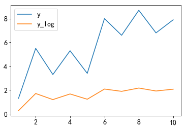

```python
# 非平稳序列转换成平稳序列
# 对数
y = np.array([1.3, 5.5, 3.3, 5.3, 3.4, 8.0, 6.6, 8.7, 6.8, 7.9])
x = list(range(1, y.shape[0]+1))

y_log = np.log(y)
# 假设这是一个时间序列图
plt.plot(x,y,label='y')
plt.plot(x,y_log,label='y_log')
plt.legend()
```

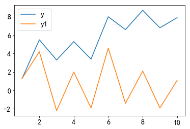

```python
# 差分
def diff(dataset):
    DIFF = []
    DIFF.append(dataset[0])# 由于差分之后的数据比原数据少一个

    # 1 次差分
    for i in range(1, dataset.shape[0]):
        value = dataset[i] - dataset[i-1]
        DIFF.append(value)

    return DIFF

y = np.array([1.3, 5.5, 3.3, 5.3, 3.4, 8.0, 6.6, 8.7, 6.8, 7.9])
y1 = diff(y)
x = list(range(1, len(y1)+1))

plt.plot(x,y,label='y')
plt.plot(x,y1,label='y1')
plt.legend()
```

从上面图像发现经过对数变换的数据明显比差分变换的效果更好，对数变换后的数据更加的平稳。 以后可以根据具体情况使用不同方法处理。

### 多个特征

#### 降维

所谓的降维就是指采用某种映射方法，将原高维空间中的数据点映射到低维度的空间中

#### 无监督之主成分分析PCA

概念及工作原理

Principal Component Analysis(PCA)是最常用的线性降维方法，它的目标是通过某种线性投影，将高维的数据映射到低维的空间中表示，并期望在所投影的维度上数据的方差最大，以此使用较少的数据维度，同时保留住较多的原数据点的特性。

用法：sklearn.decomposition.PCA(n_components=None)

```python
from sklearn.decomposition import PCA

data = [[2,8,4,5], [6,3,0,8], [5,4,9,1]]

# 1、实例化PCA, 小数——保留多少信息
transfer = PCA(n_components=0.9)
# 2、调用fit_transform
data1 = transfer.fit_transform(data)

print("保留90%的信息，降维结果为：\n", data1)

# 1、实例化PCA, 整数——指定降维到的维数
transfer2 = PCA(n_components=3)
# 2、调用fit_transform
data2 = transfer2.fit_transform(data)
print("降维到3维的结果：\n", data2)
```

```
保留90%的信息，降维结果为：
 [[ 1.28620952e-15  3.82970843e+00]
 [ 5.74456265e+00 -1.91485422e+00]
 [-5.74456265e+00 -1.91485422e+00]]
降维到3维的结果：
 [[ 1.28620952e-15  3.82970843e+00  5.26052119e-16]
 [ 5.74456265e+00 -1.91485422e+00  5.26052119e-16]
 [-5.74456265e+00 -1.91485422e+00  5.26052119e-16]]
```

#### 线性判别分析法

线性判别分析法（LDA），是一种有监督的线性降维算法。与PCA尽可能多地保留数据信息不同，LDA的目标是使降维后的数据点尽可能地容易区分，其利用了标签的信息。

```python
from sklearn.datasets import load_iris
from sklearn.discriminant_analysis import LinearDiscriminantAnalysis as LDA
iris = load_iris()
LDA(n_components=2).fit_transform(iris.data,iris.target)
```

[output not shown]

[output cut: 95 more lines]

[output not shown]

### 特征选择

当数据处理好之后，我们需要选择有意义的特征输入机器学习的模型进行训练，通常来说

#### 要从两个方面考虑来选择特征

1. 特征是否发散  
   如果一个特征不发散，例如方差接近于0，也就是说样本在这个特征上基本上没有差异，这个特征对于样本的区分并没有什么用。
2. 特征与目标的相关性  
   这点比较显见，与目标相关性高的特征，应当优先选择。  
   区别：特征与特征之间相关性高的，应当优先去除掉其中一个特征，因为它们是替代品。

#### 为什么要进行特征选择？

- 减轻维数灾难问题
- 降低学习任务的难度

#### 处理高维数据的两大主流技术

特征选择和降维

#### 特征选择有哪些方法呢？

- Filter 过滤法
- Wrapper 包装法
- Embedded 嵌入法

```python
from sklearn.datasets import load_iris

iris = load_iris()
data = pd.DataFrame(iris["data"],columns=['Sepal_Length', 'Sepal_Width', 'Petal_Length', 'Petal_Width'])
data['label'] = iris.target

print(data.shape)
data.head()
```

```
(150, 5)
```

|  | Sepal_Length | Sepal_Width | Petal_Length | Petal_Width | label |
| --- | --- | --- | --- | --- | --- |
| 0 | 5.1 | 3.5 | 1.4 | 0.2 | 0 |
| 1 | 4.9 | 3.0 | 1.4 | 0.2 | 0 |
| 2 | 4.7 | 3.2 | 1.3 | 0.2 | 0 |
| 3 | 4.6 | 3.1 | 1.5 | 0.2 | 0 |
| 4 | 5.0 | 3.6 | 1.4 | 0.2 | 0 |

##### Filter 过滤法

- 它主要侧重于单个特征跟目标变量的相关性。
- 优点是计算时间上较高效，对于过拟合问题也具有较高的鲁棒性。
- 缺点就是倾向于选择冗余的特征，因为他们不考虑特征之间的相关性,有可能某一个特征的分类能力很差，但是它和某些其它特征组合起来会得到不错的效果，这样就损失了有价值的特征。

##### 方差选择法

先从方差的概念说起，方差是衡量一个变量的离散程度(即数据偏离平均值的程度大小)，变量的方差越大，我们就可以认为它的离散程度越大，也就是意味着这个变量对模型的贡献和作用会更明显，因此要保留方差较大的变量，反之，要剔除掉无意义的特征。

思路(先计算各个特征的方差，然后根据设定的阈值或待选择阈值的个数，选择方差大于阈值的特征)

```python
# 方差选择法
# 自己手写理论公式来实现功能
def VarianceThreshold(df, threshold=0.):
    print('>>>特征名：\n', df.columns.tolist())

    # 1 求方差
    var = np.sum(np.power(np.matrix(df.values)-np.matrix(df.mean()), 2), axis=0)/df.shape[0]
    T = []
    # 2 筛选大于阈值的特征
    for index, v in enumerate(var.reshape(-1, 1)):
        if v > threshold:
            T.append(index)
    df = df.iloc[:, T]
    return var, df

# 阈值设置为 0.6
var, df = VarianceThreshold(data.iloc[:,:4], 0.60)
print('\n>>>原始特征对应的方差值：\n', var)
print('\n>>>方差阈值选择后的特征名：\n', df.columns)
df.head()
```

```
>>>特征名：
 ['Sepal_Length', 'Sepal_Width', 'Petal_Length', 'Petal_Width']

>>>原始特征对应的方差值：
 [[0.68112222 0.18871289 3.09550267 0.57713289]]

>>>方差阈值选择后的特征名：
 Index(['Sepal_Length', 'Petal_Length'], dtype='object')
```

|  | Sepal_Length | Petal_Length |
| --- | --- | --- |
| 0 | 5.1 | 1.4 |
| 1 | 4.9 | 1.4 |
| 2 | 4.7 | 1.3 |
| 3 | 4.6 | 1.5 |
| 4 | 5.0 | 1.4 |

```python
# 调用 sklearn 模块 API 接口
from sklearn.feature_selection import VarianceThreshold

vt = VarianceThreshold(0.6)
x_vt = vt.fit_transform(df.iloc[:,:4])
print(vt.variances_)
x_vt[:5]
```

```
[0.68112222 3.09550267]
```

```
array([[5.1, 1.4],
       [4.9, 1.4],
       [4.7, 1.3],
       [4.6, 1.5],
       [5. , 1.4]])
```

#### 相关系数法

##### 特征与特征的相关系数

工作原理

通过计算特征与特征之间的相关系数的大小，可判定两两特征之间的相关程度。取值区间在[-1, 1]之间，通常情况下通过以下取值范围判断变量的相关强度：

- 0.8-1.0 极强相关
- 0.6-0.8 强相关
- 0.4-0.6 中等程度相关
- 0.2-0.4 弱相关
- 0.0-0.2 极弱相关或无相关
- 原理实现：取相关系数值的绝对值，然后把corr值大于90%~95%的两两特征中的某一个特征剔除。

如果两个特征是完全线性相关的，这个时候我们只需要保留其中一个即可。因为第二个特征包含的信息完全被第一个特征所包含。此时，如果两个特征同时都保留的话，模型的性能很大情况会出现下降的情况

优缺点

- 优点：容易实现
- 缺点：只是根据特征与特征之间的相关度来筛选特征，但并没有结合与目标的相关度来衡量

应用场景

用于特征选择，以提取最有效的特征作为目标，剔除冗余特征

```python
data.iloc[:,:4].corr()
```

|  | Sepal_Length | Sepal_Width | Petal_Length | Petal_Width |
| --- | --- | --- | --- | --- |
| Sepal_Length | 1.000000 | -0.117570 | 0.871754 | 0.817941 |
| Sepal_Width | -0.117570 | 1.000000 | -0.428440 | -0.366126 |
| Petal_Length | 0.871754 | -0.428440 | 1.000000 | 0.962865 |
| Petal_Width | 0.817941 | -0.366126 | 0.962865 | 1.000000 |

#### 特征与目标的相关系数以及P值

相关性的强度确实是用相关系数的大小来衡量的，但相关大小的评价要以相关系数显著性的评价为前提。因此，要先检验相关系数的显著性，如果显著，证明相关系数有统计学意义，下一步再来看相关系数大小。  
如果相关系数没有统计学意义，那意味着你研究求得的相关系数也许是抽样误差或者测量误差造成的，再进行一次研究结果可 能就大不一样，此时讨论相关性强弱的意义就大大减弱了。

优缺点

Pearson相关系数的一个明显缺陷是，作为特征排序机制，他只对线性关系敏感。如果关系是非线性的，即便两个变量具有一一对应的关系，Pearson相关性也可能会接近0

应用场景及意义

应用于回归问题的特征选择，旨在选择出最有效的信息和减少内存占用空间

```python
from scipy.stats import pearsonr
# 相关系数--特征与目标变量(1)
def corr_selector(df,y):
    corr_list = []
    for i in df.columns.tolist():
        corr={}
        corr[i] = pearsonr(data[i],y)
        corr_list.append(corr)
    return corr_list

corr_selector(data.iloc[:,:4],data['label'])
```

```
[{'Sepal_Length': (0.7825612318100813, 2.8904783526141205e-32)},
 {'Sepal_Width': (-0.4266575607811245, 5.2015632551772934e-08)},
 {'Petal_Length': (0.9490346990083887, 4.201873152962055e-76)},
 {'Petal_Width': (0.9565473328764029, 4.1553110153181703e-81)}]
```

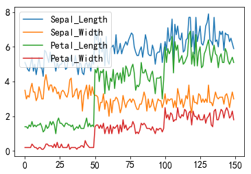

```python
data.iloc[:,:4].plot()
```

```python
# 相关系数--特征与目标变量(2)
data.iloc[:,:4].apply(lambda x,y=data['label']:pearsonr(x,y)).rename(index={0:'r',1:'p'}).T
```

|  | r | p |
| --- | --- | --- |
| Sepal_Length | 0.782561 | 2.890478e-32 |
| Sepal_Width | -0.426658 | 5.201563e-08 |
| Petal_Length | 0.949035 | 4.201873e-76 |
| Petal_Width | 0.956547 | 4.155311e-81 |

##### 卡方检验

卡方检验是一种用途很广的计数资料的假设检验方法。属于非参数检验，主要是比较两个及两个以上样本率（构成比）以及两个分类变量的关联性分析。理论如下：

假设检验：

- 假如提出原假设H0：化妆与性别没有关系；
- 备用假设H1：化妆与性别有显著关系。

应用场景及意义

应用场景：适用于分类问题的分类变量

```python
# 调用 sklearn 模块 API 接口
from sklearn.feature_selection import SelectKBest
from sklearn.feature_selection import chi2

skb = SelectKBest(chi2, k=2)
x_skb = skb.fit_transform(data.iloc[:,:4], data.iloc[:,4])
print('>>>检验统计值(卡方值)：\n', skb.scores_)
print('\n>>>P值：\n', skb.pvalues_)
```

```
>>>检验统计值(卡方值)：
 [ 10.81782088   3.7107283  116.31261309  67.0483602 ]

>>>P值：
 [4.47651499e-03 1.56395980e-01 5.53397228e-26 2.75824965e-15]
```

#### Wrapper 包装法

封装器用选取的特征子集对样本(标签)集进行训练学习，训练的精度(准确率)作为衡量特征子集好坏的标准,经过比较选出最好的特征子集。

常用的有逐步回归（Stepwise regression）、向前选择（Forward selection）和向后选择（Backward selection）。

它的优点是：考虑了特征之间组合以及特征与标签之间的关联性；

缺点是：当观测数据较少时容易过拟合，而当特征数量较多时,计算时间又会增长。

工作原理

包装法是指使用算法模型对特征子集与目标(标签)集进行训练评估，根据训练的精度(准确率)衡量特征子集的好坏，从而挑选出最好的特征子集。

优缺点

- 优点：考虑了特征之间组合以及特征与标签之间的关联性。
- 缺点：由于要划分特征为特征子集并且逐个训练评分，因此当特征数量较多时,计算时间又会增长；另外在样本数据较少的时候，容易过拟合。

#### 稳定性选择

工作原理

稳定性选择是一种基于二次抽样和选择算法(训练模型)相结合的方法，选择算法可以是回归、分类SVM或者类似算法。

原理实现：在不同的特征子集上运行训练模型，不断地重复，最终汇总特征选择的结果。比如可以统计某个特征被认为是重要特征的频率（被选为重要特征的次数除以它所在的子集被测试的次数）。理想情况下，重要特征的得分会接近100%。稍微弱一点的特征得分会是非0的数，而最无用的特征得分将会接近于0。

优缺点

```python
from sklearn.linear_model import LinearRegression

X = data.iloc[:,:4]
Y = data.iloc[:,4]
names = X.columns.tolist()
print(names)

# -------------------------------------回归
lr = LinearRegression()
lr.fit(X,Y)
print(lr.coef_, lr.intercept_)
```

```
['Sepal_Length', 'Sepal_Width', 'Petal_Length', 'Petal_Width']
[-0.11190585 -0.04007949  0.22864503  0.60925205] 0.1864952472062491
```

```python
from sklearn.svm import SVC

X1, X2, Y = data[['Petal_Width']], data[['Sepal_Width']], data['label']
svc = SVC()
for X in [X1, X2]:
    svc.fit(X,Y)
    print(svc.score(X,Y))
```

```
0.96
0.5533333333333333
```

#### 递归特征消除

工作原理

- 反复的构建模型(比如SVM或者回归模型)
- 接着选出最好(或者最差)的特征(可以根据系数来选)，把选出来的特征放到一边
- 然后在剩余的特征上重复上面(1)(2)步骤，直到遍历完所有特征。

通俗来说：

RFE算法的主要思想就是使用一个基模型（这里是S模型VM）来进行多轮训练，每轮训练后，根据每个特征的系数对特征打分，去掉得分最小的特征，然后用剩余的特征构建新的特征集，进行下一轮训练，直到所有的特征都遍历了。

这个过程中特征被消除的次序就是特征的排序，实际上这是一种寻找最优特征子集的贪心算法。

优缺点

RFE的稳定性很大程度上取决于在迭代选择的时候，选择哪一种模型。

- 如果RFE采用的是普通的回归，没有经过正则化的回归是不稳定的，从而RFE也是不稳定的
- 如果采用Ridge或Lasso模型，经过正则化的回归是稳定的，从而RFE是稳定的。

```python
from sklearn.feature_selection import RFE
from sklearn.linear_model import LinearRegression
from sklearn.datasets import load_boston

boston = load_boston()
X = boston["data"]
Y = boston["target"]
names = boston["feature_names"]

#use linear regression as the model
lr = LinearRegression()
#rank all features, i.e continue the elimination until the last one
rfe = RFE(lr, n_features_to_select=3)
rfe.fit(X,Y)

print("Features sorted by their rank:")
print(sorted(zip(rfe.ranking_, names)))
```

```
Features sorted by their rank:
[(1, 'CHAS'), (1, 'NOX'), (1, 'RM'), (2, 'PTRATIO'), (3, 'DIS'), (4, 'LSTAT'), (5, 'RAD'), (6, 'CRIM'), (7, 'INDUS'), (8, 'ZN'), (9, 'TAX'), (10, 'B'), (11, 'AGE')]
```

#### Embedded 嵌入法

集成法，先使用某些机器学习的算法和模型进行训练，得到各个特征的权重值系数，根据系数从大到小选择特征。

类似于Filter方法，但是是通过训练来确定特征的优劣。

例如使用决策树思想，Random Forest和Gradient boosting等

#### 包装法与嵌入法的区别

包装法根据预测效果评分来选择，而嵌入法根据预测后的特征权重值系数来选择。

#### 工作原理

先使用某些机器学习的算法和模型进行训练，得到各个特征的权值系数，根据系数从大到小选择特征。

有些机器学习方法本身就具有对特征进行打分的机制，或者很容易将其运用到特征选择任务中，例如回归模型，SVM，树模型(决策树、随机森林)等等

#### 线性模型

工作原理

越是重要的特征在模型中对应的系数就会越大，而跟目标(标签)变量越是无关的特征对应的系数就会越接近于0。

线性模型

在噪音不多的数据上，或者是数据量远远大于特征数的数据上，如果特征之间相对来说是比较独立的，那么即便是运用最简单的线性回归模型也一样能取得非常好的效果

优缺点

- 如果特征之间存在多个互相关联的特征，模型就会变得很不稳定
- 对噪声很敏感，数据中细微的变化就可能导致模型发生巨大的变化

```python
from sklearn.linear_model import LinearRegression

X = data.iloc[:,:4]
Y = data.iloc[:,4]
lr = LinearRegression()
lr.fit(X,Y)
print(X.columns.tolist())
print(lr.coef_)
```

```
['Sepal_Length', 'Sepal_Width', 'Petal_Length', 'Petal_Width']
[-0.11190585 -0.04007949  0.22864503  0.60925205]
```

##### 正则化

在学习的时候，数据提供的特征有些影响模型复杂度或者这个特征的数据点异常较多，所以算法在学习的时候尽量减少这个特征的影响（甚至删除某个特征的影响），这就是正则化

注：调整时候，算法并不知道某个特征影响，而是去调整参数得出优化的结果。

L2正则化

- 作用：可以使得其中一些W的都很小，都接近于0，削弱某个特征的影响
- 优点：越小的参数说明模型越简单，越简单的模型则越不容易产生过拟合现象
- Ridge回归  
  L1正则化
- 作用：可以使得其中一些W的值直接为0，删除这个特征的影响
- LASSO回归

概念

正则化就是把额外的约束或者惩罚项加到已有模型（损失函数）上，以防止过拟合并提高泛化能力。

工作原理

L1正则化Lasso(least absolute shrinkage and selection operator)将系数w的l1范数作为惩罚项加到损失函数上，由于正则项非零，这就迫使那些弱的特征所对应的系数变成0。因此L1正则化往往会使学到的模型很稀疏（系数w经常为0），这个特性使得L1正则化成为一种很好的特征选择方法。

L2正则化同样将系数向量的L2范数添加到了损失函数中。由于L2惩罚项中系数是二次方的，这使得L2和L1有着诸多差异，最明显的一点就是，L2正则化会让系数的取值变得平均。

优缺点

L1正则化缺点：L1正则化像非正则化线性模型一样也是不稳定的，如果特征集合中具有相关联的特征，当数据发生细微变化时也有可能导致很大的模型差异。

L2正则化优点：L2正则化对于特征选择来说一种稳定的模型，不像L1正则化那样，系数会因为细微的数据变化而波动。

总结：L2正则化和L1正则化提供的价值是不同的，L2正则化对于特征理解来说更加有用：表示能力强的特征对应的系数是非零。

```python
from sklearn.linear_model import Lasso

X = data.iloc[:,:4]
Y = data.iloc[:,4]
lasso = Lasso(alpha=0.3)
lasso.fit(X,Y)
print(X.columns.tolist())
print(lasso.coef_)
```

```
['Sepal_Length', 'Sepal_Width', 'Petal_Length', 'Petal_Width']
[ 0.        -0.         0.3435091  0.       ]
```

由上面情况来看，L1范数正则化效果非常差，几乎特征都被弱化了，不知道哪一些重要

```python
from sklearn.linear_model import Ridge

X = data.iloc[:,:4]
Y = data.iloc[:,4]
ridge = Ridge(alpha=0.3)
ridge.fit(X,Y)
print(X.columns.tolist())
print(ridge.coef_)
```

```
['Sepal_Length', 'Sepal_Width', 'Petal_Length', 'Petal_Width']
[-0.11327412 -0.03665944  0.23969479  0.58451798]
```

由上面情况来看，L2范数正则化从返回的回归系数就可以知道模型比较稳定，并且效果不错。